# Movie Review Topic Discovery Using LSA

Sentiment analysis in R on the IMDb Large Movie Review Dataset

17 October 2026

This notebook implements the six-stage pipeline proposed in the project report: **clean → tokenize & tf-idf → document-term matrix → LSA topics → lexicon sentiment → validation**. Every number and chart below is produced by running the code on the data.

# 1 Setup

```r
library(readr)
library(dplyr)
library(tidyr)
library(stringr)
library(forcats)
library(ggplot2)
library(scales)
library(tidytext)
library(Matrix)
library(irlba)        # fast truncated SVD on a sparse matrix
library(wordcloud)
library(RColorBrewer)
library(reshape2)
library(caret)        # confusion matrices
library(glmnet)       # regularised logistic regression
library(lime)         # local explanations of the classifier

set.seed(2026)
theme_set(theme_minimal(base_size = 12))
dir.create("outputs", showWarnings = FALSE)

N_PER_CLASS <- 5000   # reviews sampled per class (report: 5k-10k total is enough)
K_TOPICS    <- 10     # number of LSA topics kept (justified by the scree plot)
```

Sentiment lexicons. Bing ships with **tidytext**; AFINN and NRC are fetched once with **textdata** by `get_lexicons.R` and cached in `lexicons/`.

```r
afinn <- readRDS("lexicons/afinn/afinn.rds")
bing  <- get_sentiments("bing")
nrc   <- readRDS("lexicons/nrc/nrc.rds")

tibble(lexicon = c("AFINN", "Bing", "NRC"),
       words   = c(nrow(afinn), nrow(bing), n_distinct(nrc$word)),
       scoring = c("integer -5 .. +5", "positive / negative",
                   "positive / negative + 8 emotions"))
```

| lexicon | words | scoring |
| --- | --- | --- |
| AFINN | 2477 | integer -5 .. +5 |
| Bing | 6786 | positive / negative |
| NRC | 6453 | positive / negative + 8 emotions |

# 2 Stage 1 – Explore and clean the text

```r
reviews_all <- read_csv("data/imdb_reviews.csv", show_col_types = FALSE)

reviews <- reviews_all |>
  group_by(sentiment) |>
  slice_sample(n = N_PER_CLASS) |>
  ungroup() |>
  mutate(id = row_number())

cat("Full dataset:", nrow(reviews_all), "reviews | analysed sample:",
    nrow(reviews), "reviews\n")
```

```
## Full dataset: 50000 reviews | analysed sample: 10000 reviews
```

```r
count(reviews_all, sentiment, name = "reviews_in_full_dataset")
```

| sentiment | reviews_in_full_dataset |
| --- | --- |
| negative | 25000 |
| positive | 25000 |

```r
clean_text <- function(x) {
  x |>
    str_replace_all("<[^>]+>", " ") |>      # HTML tags such as <br />
    str_to_lower() |>
    str_replace_all("[^a-z' ]", " ") |>      # punctuation and numbers
    str_replace_all("(^| )'+|'+( |$)", " ") |>
    str_squish()
}

reviews <- reviews |>
  mutate(clean   = clean_text(review),
         n_words = str_count(clean, "\\S+"))

reviews |> select(review) |> slice(1) |> pull() |> str_trunc(400) |> cat()
```

```
## Amazing. That's what you'd say if you sat through this film. Simply, incredibly, amazing. It's actually so amazing that anyone was stupid enough to dump money into making this monstrosity that you simply can't believe what you're seeing. That, my friends, is what is truly scary about this film. S…
```

```r
cat("\n\n--- after cleaning ---\n\n")
```

```
##
##
## --- after cleaning ---
```

```r
reviews |> select(clean)  |> slice(1) |> pull() |> str_trunc(400) |> cat()
```

```
## amazing that's what you'd say if you sat through this film simply incredibly amazing it's actually so amazing that anyone was stupid enough to dump money into making this monstrosity that you simply can't believe what you're seeing that my friends is what is truly scary about this film somebody t…
```

```r
reviews |>
  group_by(sentiment) |>
  summarise(reviews       = n(),
            mean_words    = round(mean(n_words)),
            median_words  = median(n_words),
            min_words     = min(n_words),
            max_words     = max(n_words),
            mean_stars    = round(mean(rating), 2))
```

| sentiment | reviews | mean_words | median_words | min_words | max_words | mean_stars |
| --- | --- | --- | --- | --- | --- | --- |
| negative | 5000 | 228 | 173 | 6 | 1377 | 2.21 |
| positive | 5000 | 232 | 171 | 12 | 2113 | 8.76 |

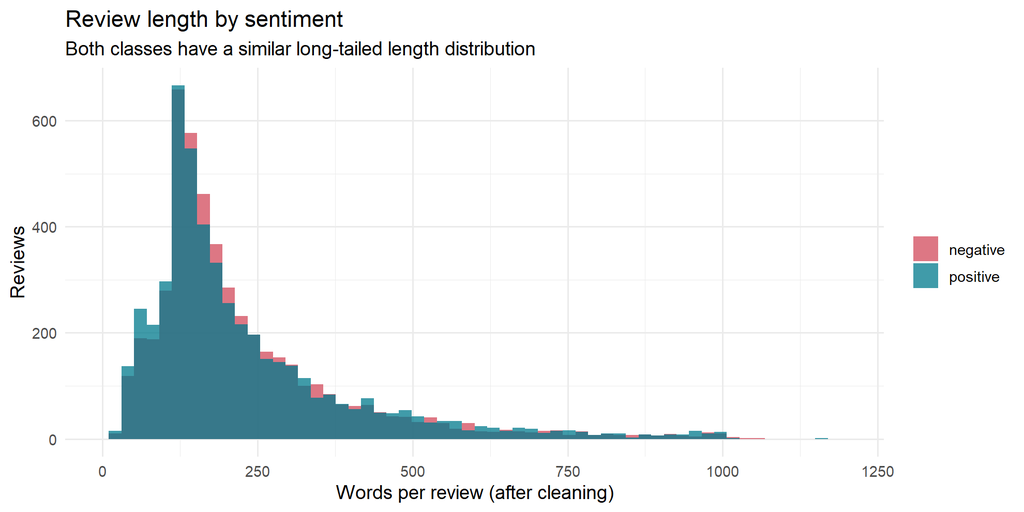

```r
ggplot(reviews, aes(n_words, fill = sentiment)) +
  geom_histogram(bins = 60, alpha = 0.75, position = "identity") +
  scale_x_continuous(limits = c(0, 1200)) +
  scale_fill_manual(values = c(negative = "#d1495b", positive = "#00798c")) +
  labs(title = "Review length by sentiment",
       subtitle = "Both classes have a similar long-tailed length distribution",
       x = "Words per review (after cleaning)", y = "Reviews", fill = NULL)
```

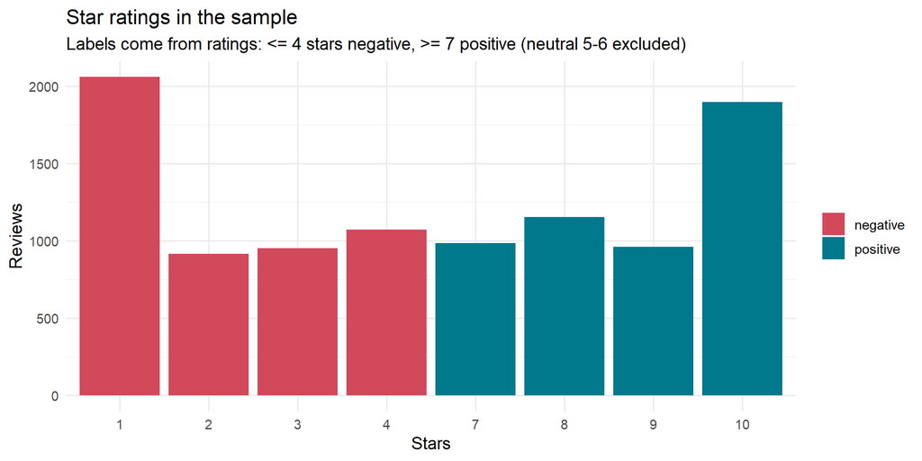

```r
reviews |>
  count(rating, sentiment) |>
  ggplot(aes(factor(rating), n, fill = sentiment)) +
  geom_col() +
  scale_fill_manual(values = c(negative = "#d1495b", positive = "#00798c")) +
  labs(title = "Star ratings in the sample",
       subtitle = "Labels come from ratings: <= 4 stars negative, >= 7 positive (neutral 5-6 excluded)",
       x = "Stars", y = "Reviews", fill = NULL)
```

# 3 Stage 2 – Tokenize, word frequency and tf-idf

`unnest_tokens()` gives one word per row. Two token tables are kept: `tokens_all` (every word, used for sentiment so that words such as *not* stay available) and `tokens` (stop words removed, used for frequency, tf-idf and LSA).

```r
tokens_all <- reviews |>
  select(id, sentiment, clean) |>
  unnest_tokens(word, clean) |>
  group_by(id) |>
  mutate(position = row_number()) |>
  ungroup()

# Domain words that appear everywhere and carry no topic information
domain_stop <- tibble(word = c("movie", "movies", "film", "films", "br",
                               "time", "watch", "watching", "watched",
                               "people", "lot", "makes", "bit", "thing"))

tokens <- tokens_all |>
  anti_join(stop_words, by = "word") |>
  filter(str_length(word) > 2)

cat("Tokens (all words):", format(nrow(tokens_all), big.mark = ","),
    "\nTokens (stop words removed):", format(nrow(tokens), big.mark = ","),
    "\nDistinct words:", format(n_distinct(tokens$word), big.mark = ","), "\n")
```

```
## Tokens (all words): 2,300,509
## Tokens (stop words removed): 860,552
## Distinct words: 54,415
```

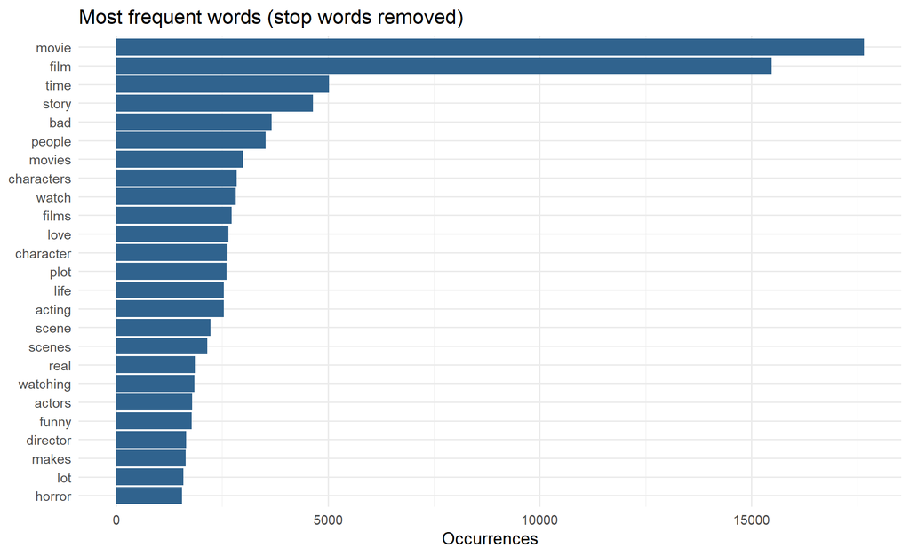

```r
word_counts <- tokens |> count(word, sort = TRUE)

word_counts |>
  slice_head(n = 25) |>
  ggplot(aes(n, fct_reorder(word, n))) +
  geom_col(fill = "#30638e") +
  labs(title = "Most frequent words (stop words removed)",
       x = "Occurrences", y = NULL)
```

**Zipf’s law.** A handful of words dominate raw counts – frequency falls roughly in proportion to 1 / rank – which is why raw counts alone are a poor measure of how informative a word is.

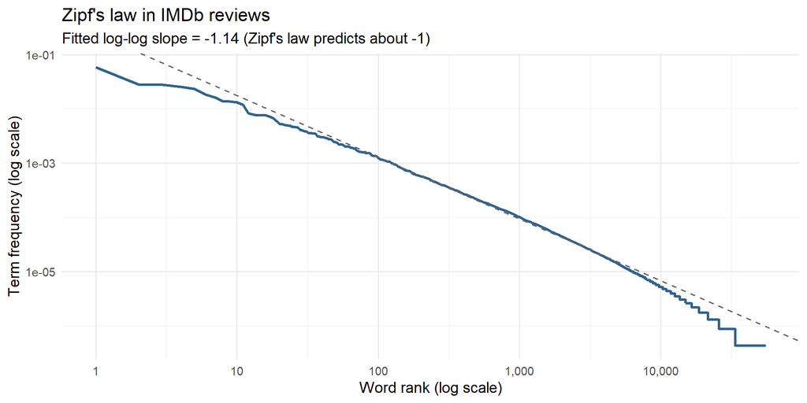

```r
zipf <- tokens_all |>
  count(word, sort = TRUE) |>
  mutate(rank = row_number(), freq = n / sum(n))

zipf_fit <- lm(log10(freq) ~ log10(rank), data = filter(zipf, rank <= 5000))

ggplot(zipf, aes(rank, freq)) +
  geom_line(colour = "#30638e", linewidth = 1) +
  geom_abline(intercept = coef(zipf_fit)[1], slope = coef(zipf_fit)[2],
              linetype = "dashed", colour = "grey40") +
  scale_x_log10(labels = comma) + scale_y_log10() +
  labs(title = "Zipf's law in IMDb reviews",
       subtitle = sprintf("Fitted log-log slope = %.2f (Zipf's law predicts about -1)",
                          coef(zipf_fit)[2]),
       x = "Word rank (log scale)", y = "Term frequency (log scale)")
```

**tf-idf.** `bind_tf_idf()` weights each word in each review by how often it appears there (*tf*) and how rare it is across all reviews (*idf*). Words that are distinctive for a few reviews score high; words found everywhere score close to zero.

```r
review_tfidf <- tokens |>
  count(id, word) |>
  bind_tf_idf(word, id, n)

# Words that are both reasonably common and distinctive where they occur
review_tfidf |>
  group_by(word) |>
  summarise(reviews = n(), idf = first(idf), mean_tf_idf = mean(tf_idf)) |>
  filter(reviews >= 50) |>
  arrange(desc(mean_tf_idf)) |>
  slice_head(n = 15) |>
  mutate(across(c(idf, mean_tf_idf), \(x) round(x, 3)))
```

| word | reviews | idf | mean_tf_idf |
| --- | --- | --- | --- |
| batman | 61 | 5.099 | 0.156 |
| kung | 50 | 5.298 | 0.126 |
| keaton | 50 | 5.298 | 0.118 |
| eddie | 67 | 5.006 | 0.114 |
| drew | 54 | 5.221 | 0.113 |
| brooks | 52 | 5.259 | 0.113 |
| cartoons | 59 | 5.133 | 0.113 |
| vampire | 97 | 4.636 | 0.112 |
| season | 139 | 4.276 | 0.110 |
| davis | 69 | 4.976 | 0.109 |
| graphics | 55 | 5.203 | 0.108 |
| jesus | 51 | 5.279 | 0.106 |
| concert | 50 | 5.298 | 0.104 |
| shorts | 55 | 5.203 | 0.104 |
| rose | 51 | 5.279 | 0.103 |

Distinctive vocabulary of each star rating (each rating group treated as one “document”):

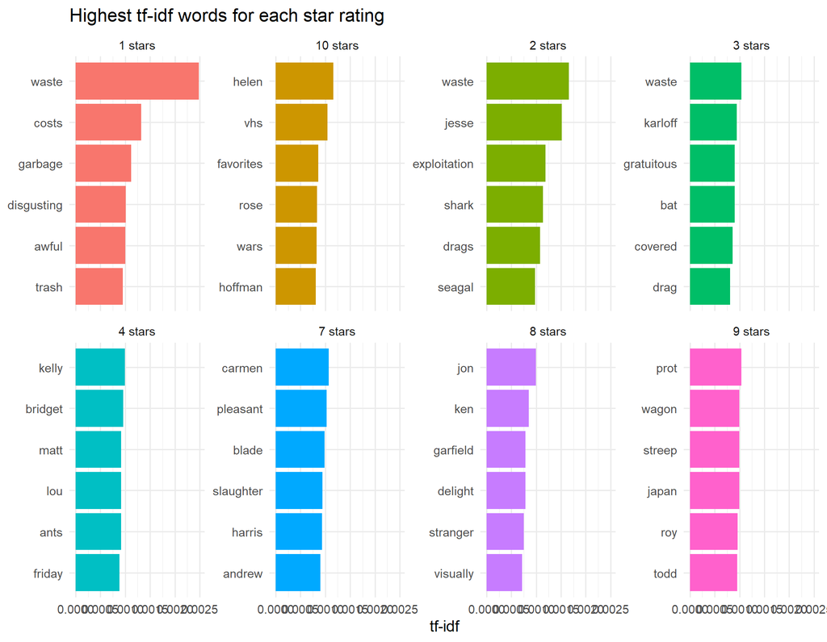

```r
tokens |>
  left_join(select(reviews, id, rating), by = "id") |>
  count(rating, word) |>
  filter(n >= 15) |>
  bind_tf_idf(word, rating, n) |>
  group_by(rating) |>
  slice_max(tf_idf, n = 6, with_ties = FALSE) |>
  ungroup() |>
  mutate(rating = paste(rating, "stars"),
         word   = reorder_within(word, tf_idf, rating)) |>
  ggplot(aes(tf_idf, word, fill = rating)) +
  geom_col(show.legend = FALSE) +
  scale_y_reordered() +
  facet_wrap(~ rating, scales = "free_y", ncol = 4) +
  labs(title = "Highest tf-idf words for each star rating",
       x = "tf-idf", y = NULL)
```

# 4 Stage 3 – Document-term matrix

Rows are reviews, columns are terms, values are tf-idf weights. Very rare terms (in fewer than 20 reviews) and near-universal ones (more than 30 % of reviews) are dropped, and each row is scaled to unit length so that long reviews do not dominate the decomposition.

```r
doc_freq <- tokens |>
  anti_join(domain_stop, by = "word") |>
  distinct(id, word) |>
  count(word, name = "df")

vocab <- doc_freq |>
  filter(df >= 20, df <= 0.30 * nrow(reviews)) |>
  pull(word) |>
  sort()

idf_lookup <- review_tfidf |>
  filter(word %in% vocab) |>
  distinct(word, idf)
idf_vec <- setNames(idf_lookup$idf, idf_lookup$word)[vocab]

# Turns any character vector of reviews into an L2-normalised tf-idf matrix
# over the fixed vocabulary (re-used later by the classifier and LIME).
text_to_dtm <- function(texts) {
  td <- tibble(doc = seq_along(texts), text = clean_text(texts)) |>
    unnest_tokens(word, text) |>
    filter(word %in% vocab) |>
    count(doc, word) |>
    group_by(doc) |>
    mutate(w = n / sum(n) * idf_vec[word]) |>
    ungroup()
  m <- sparseMatrix(i = td$doc, j = match(td$word, vocab), x = td$w,
                    dims = c(length(texts), length(vocab)),
                    dimnames = list(NULL, vocab))
  norms <- sqrt(rowSums(m^2))
  norms[norms == 0] <- 1
  Diagonal(x = 1 / norms) %*% m
}

dtm <- text_to_dtm(reviews$review)

cat(sprintf("Document-term matrix: %s reviews x %s terms, %.2f%% non-zero\n",
            comma(nrow(dtm)), comma(ncol(dtm)),
            100 * length(dtm@x) / prod(dim(dtm))))
```

```
## Document-term matrix: 10,000 reviews x 5,724 terms, 0.92% non-zero
```

# 5 Stage 4 – Topic discovery with LSA

LSA factorises the matrix with a truncated SVD: **A ≈ U<sub>k</sub> Σ<sub>k</sub> V<sub>k</sub><sup>T</sup>**. `irlba` computes the leading 50 singular vectors directly on the sparse matrix, which is far cheaper than a full dense SVD.

```r
svd50 <- irlba(dtm, nv = 50, nu = 50)

total_var <- sum(dtm^2)                      # squared Frobenius norm
scree <- tibble(dimension = 1:50,
                var_explained = svd50$d^2 / total_var) |>
  mutate(cumulative = cumsum(var_explained))
```

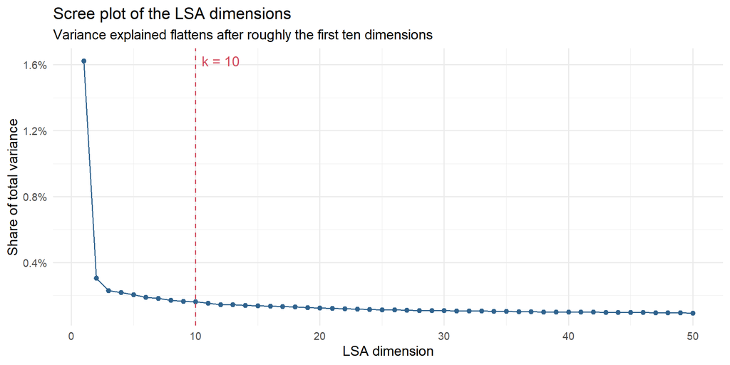

```r
ggplot(scree, aes(dimension, var_explained)) +
  geom_line(colour = "#30638e") +
  geom_point(colour = "#30638e") +
  geom_vline(xintercept = K_TOPICS, linetype = "dashed", colour = "#d1495b") +
  annotate("text", x = K_TOPICS + 0.5, y = max(scree$var_explained),
           label = paste("k =", K_TOPICS), hjust = 0, colour = "#d1495b") +
  scale_y_continuous(labels = percent_format(accuracy = 0.1)) +
  labs(title = "Scree plot of the LSA dimensions",
       subtitle = "Variance explained flattens after roughly the first ten dimensions",
       x = "LSA dimension", y = "Share of total variance")
```

```r
scree |> filter(dimension %in% c(1, 5, 10, 20, 50)) |>
  mutate(across(-dimension, \(x) percent(x, accuracy = 0.01)))
```

| dimension | var_explained | cumulative |
| --- | --- | --- |
| 1 | 1.62% | 1.62% |
| 5 | 0.20% | 2.58% |
| 10 | 0.16% | 3.45% |
| 20 | 0.12% | 4.82% |
| 50 | 0.09% | 7.95% |

Text matrices have a very flat spectrum, so k cannot be chosen from a variance target such as 80 %: the scree plot’s elbow is used instead, and **k = 10** is kept.

**Raw LSA dimensions.** Loadings can be positive *or* negative, and the first dimension simply captures the vocabulary shared by all reviews. This is the interpretability problem the report mentions:

```r
raw_v <- svd50$v[, 1:4]
rownames(raw_v) <- vocab
lapply(1:4, function(j) {
  tibble(dimension = j,
         `top positive terms` = paste(names(sort(raw_v[, j], decreasing = TRUE))[1:8], collapse = ", "),
         `top negative terms` = paste(names(sort(raw_v[, j]))[1:8], collapse = ", "))
}) |> bind_rows()
```

| dimension | top positive terms | top negative terms |
| --- | --- | --- |
| 1 | bad, characters, acting, love, plot, character, life, funny | controlling, begun, lunatic, assumes, realization, otto, prostitutes, youthful |
| 2 | bad, horror, worst, acting, waste, terrible, stupid, awful | love, war, life, beautiful, family, role, series, wonderful |
| 3 | series, episode, episodes, season, funny, original, dvd, jokes | horror, director, killer, woman, scene, gore, performance, women |
| 4 | funny, bad, comedy, jokes, love, waste, worst, laugh | horror, series, episode, gore, killer, effects, episodes, budget |

**Rotated topics.** To make the k dimensions readable, the term loadings are rotated with **varimax** (a standard step in LSA and factor analysis). The rotation spans exactly the same k-dimensional space, but concentrates each topic on a smaller set of words. Each topic is oriented so its strongest words load positively.

```r
V <- svd50$v[, 1:K_TOPICS]
rot <- varimax(V, normalize = FALSE)
loadings <- unclass(rot$loadings)
rownames(loadings) <- vocab

orientation <- apply(loadings, 2, function(col) sign(col[which.max(abs(col))]))
loadings <- sweep(loadings, 2, orientation, `*`)
colnames(loadings) <- paste0("T", 1:K_TOPICS)

topic_terms <- as_tibble(loadings, rownames = "term") |>
  pivot_longer(-term, names_to = "topic", values_to = "loading") |>
  group_by(topic) |>
  slice_max(loading, n = 12, with_ties = FALSE) |>
  ungroup()

topic_terms |>
  group_by(topic) |>
  summarise(top_terms = paste(term, collapse = ", ")) |>
  arrange(as.integer(str_remove(topic, "T")))
```

| topic | top_terms |
| --- | --- |
| T1 | role, performance, character, cast, actors, characters, excellent, actor, performances, plays, script, director |
| T2 | bad, worst, acting, terrible, awful, waste, horrible, worse, money, plot, script, guy |
| T3 | series, episode, episodes, season, original, television, characters, sci, dvd, seasons, fan, columbo |
| T4 | horror, gore, scary, slasher, budget, killer, house, creepy, genre, effects, low, suspense |
| T5 | funny, comedy, jokes, laugh, humor, stupid, fun, hilarious, joke, funniest, laughs, comedies |
| T6 | book, read, original, books, adaptation, version, reading, comic, based, jane, disappointed, scarlett |
| T7 | kids, guy, girl, house, family, game, fun, car, killer, girls, father, kill |
| T8 | love, music, dvd, loved, kids, wonderful, enjoy, beautiful, songs, family, video, amazing |
| T9 | action, dvd, budget, effects, game, original, fun, special, version, music, low, video |
| T10 | war, world, documentary, life, american, german, human, history, budget, waste, stupid, worst |

Each topic is named from its highest-loading terms:

```r
topic_labels <- c(
  T1  = "Acting & performances",
  T2  = "Bad acting & wasted money",
  T3  = "TV series & episodes",
  T4  = "Horror & slashers",
  T5  = "Comedy & humour",
  T6  = "Book adaptations",
  T7  = "Family & thriller plots",
  T8  = "Music, love & family viewing",
  T9  = "Action & special effects",
  T10 = "War, history & documentaries"
)
topic_labels
```

```
##                             T1                             T2
##        "Acting & performances"    "Bad acting & wasted money"
##                             T3                             T4
##         "TV series & episodes"            "Horror & slashers"
##                             T5                             T6
##              "Comedy & humour"             "Book adaptations"
##                             T7                             T8
##      "Family & thriller plots" "Music, love & family viewing"
##                             T9                            T10
##     "Action & special effects" "War, history & documentaries"
```

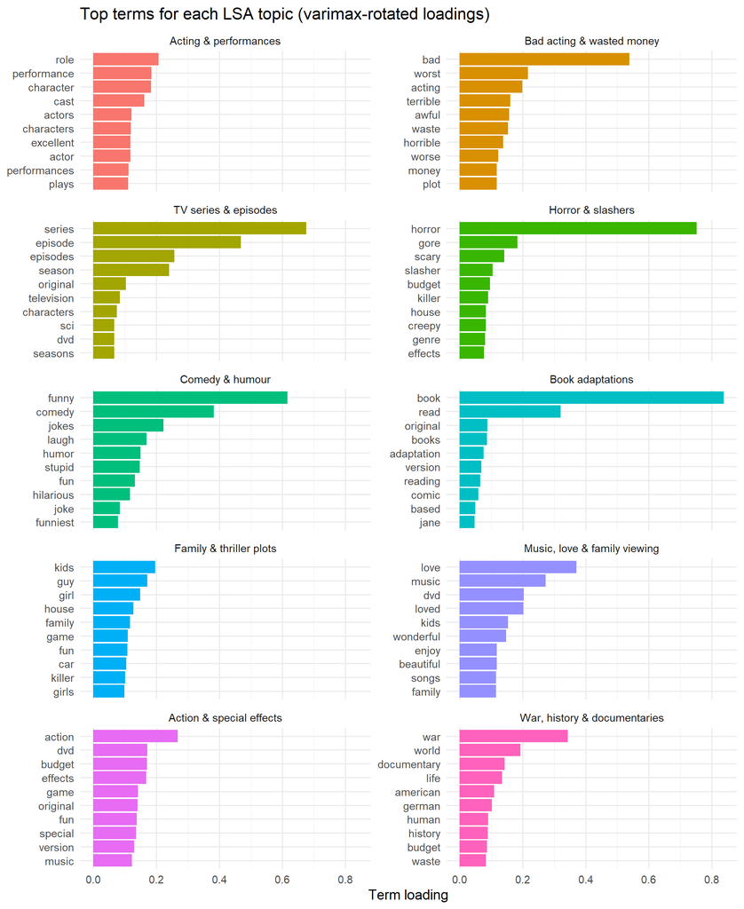

```r
topic_terms |>
  group_by(topic) |>
  slice_max(loading, n = 10, with_ties = FALSE) |>
  ungroup() |>
  mutate(label = factor(topic_labels[topic], levels = topic_labels),
         term  = reorder_within(term, loading, label)) |>
  ggplot(aes(loading, term, fill = label)) +
  geom_col(show.legend = FALSE) +
  scale_y_reordered() +
  facet_wrap(~ label, scales = "free_y", ncol = 2) +
  labs(title = "Top terms for each LSA topic (varimax-rotated loadings)",
       x = "Term loading", y = NULL)
```

Every review gets a score on each topic (its projection onto the rotated loadings) and is assigned to the topic it scores highest on.

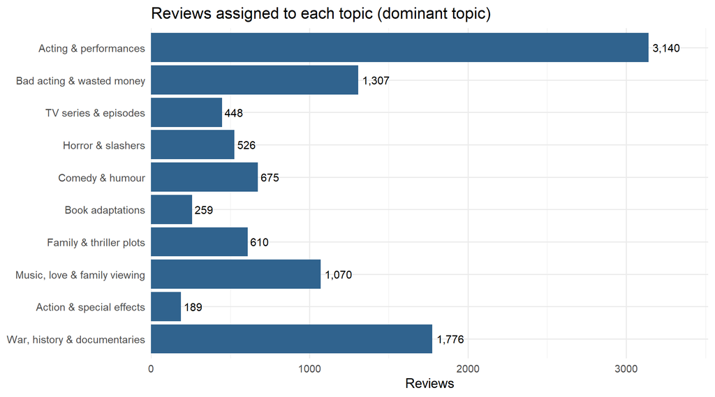

```r
doc_scores <- as.matrix(dtm %*% loadings)

reviews <- reviews |>
  mutate(topic       = colnames(doc_scores)[max.col(doc_scores, ties.method = "first")],
         topic_label = factor(topic_labels[topic], levels = topic_labels),
         topic_score = apply(doc_scores, 1, max))

reviews |>
  count(topic_label) |>
  ggplot(aes(n, fct_rev(topic_label))) +
  geom_col(fill = "#30638e") +
  geom_text(aes(label = comma(n)), hjust = -0.15, size = 3.5) +
  scale_x_continuous(expand = expansion(mult = c(0, 0.12))) +
  labs(title = "Reviews assigned to each topic (dominant topic)",
       x = "Reviews", y = NULL)
```

Example review snippets for each topic (the review scoring highest on it):

```r
reviews |>
  group_by(topic_label) |>
  slice_max(topic_score, n = 1, with_ties = FALSE) |>
  ungroup() |>
  transmute(topic = topic_label, sentiment,
            snippet = str_trunc(str_squish(str_replace_all(review, "<[^>]+>", " ")), 180))
```

| topic | sentiment | snippet |
| --- | --- | --- |
| Acting & performances | positive | A DOUBLE LIFE has developed a mystique among film fans for two reasons: the plot idea of an actor getting so wrapped up into a role (here Othello) as to pick up the great flaw o… |
| Bad acting & wasted money | negative | This movie is so bad it’s almost good. Bad story, bad acting, bad music, you name it. O.K., who are the jokers that gave this flick a ‘10’? |
| TV series & episodes | positive | I got this as a complete set of 9 episodes on 5 DVDs. I knew nothing about the history of the series. Season 1 of the series has the pilot episode as episode 1 and then 3 more e… |
| Horror & slashers | negative | I am the guy who usually keeps opinions to himself, but I just got back from this movie, and felt I had to express my opinions. Let me start by saying that I am a HUGE horror fa… |
| Comedy & humour | negative | I was expecting a very funny movie. Instead, I got a movie with a few funny jokes, and many that just didn’t work. I didn’t like the idea of bringing in Sherlock Holmes’ and Mor… |
| Book adaptations | negative | This movie is a good example of how to ruin a book in 109 minutes. Except for the names of the characters the movie bears very little resemblance to the book. A book full of str… |
| Family & thriller plots | positive | Dead To Rights is about a Police Officer named Jack Slate who finds his murdered father and goes after the man that he thinks killed him.Jack is later shot and framed for the mu… |
| Music, love & family viewing | positive | I’ve loved this movie ever since it first came out. I was about nine years old, and now I’m 27. I remember playing the video game on Sega Genisis. I had so much fun, I would lov… |
| Action & special effects | positive | This movie is very similar to Death Warrant with Jean-Claude Van Damme and also has some similarities to Island of Fire with Jackie Chan and I also heard that there is some othe… |
| War, history & documentaries | positive | Example of how a World War 2 documentary should be made,using first hand accounts from actual troops and civilians whom participated in this awful conflict,and archived footage … |

# 6 Stage 5 – Sentiment analysis with three dictionaries

Each review is scored with every lexicon using **all** of its words (stop-word lists contain words like *not* and *well* that matter for opinion).

- **AFINN** – sum of word scores (-5 … +5)
- **Bing** – positive words minus negative words
- **NRC** – positive minus negative words, plus counts for 8 emotions

```r
words_only <- select(tokens_all, id, word)

afinn_scores <- words_only |>
  inner_join(afinn, by = "word") |>
  group_by(id) |>
  summarise(afinn = sum(value), afinn_words = n())

bing_scores <- words_only |>
  inner_join(bing, by = "word") |>
  count(id, sentiment) |>
  pivot_wider(names_from = sentiment, values_from = n, values_fill = 0) |>
  transmute(id, bing = positive - negative, bing_words = positive + negative)

nrc_polarity <- words_only |>
  inner_join(filter(nrc, sentiment %in% c("positive", "negative")),
             by = "word", relationship = "many-to-many") |>
  count(id, sentiment) |>
  pivot_wider(names_from = sentiment, values_from = n, values_fill = 0) |>
  transmute(id, nrc = positive - negative)

nrc_emotions <- words_only |>
  inner_join(filter(nrc, !sentiment %in% c("positive", "negative")),
             by = "word", relationship = "many-to-many") |>
  count(id, sentiment) |>
  pivot_wider(names_from = sentiment, values_from = n, values_fill = 0)

scored <- reviews |>
  select(id, sentiment, rating, n_words, topic, topic_label) |>
  left_join(afinn_scores, by = "id") |>
  left_join(bing_scores,  by = "id") |>
  left_join(nrc_polarity, by = "id") |>
  mutate(across(c(afinn, afinn_words, bing, bing_words, nrc), \(x) coalesce(x, 0)))

scored |>
  group_by(sentiment) |>
  summarise(across(c(afinn, bing, nrc), \(x) round(mean(x), 2), .names = "mean_{.col}"))
```

| sentiment | mean_afinn | mean_bing | mean_nrc |
| --- | --- | --- | --- |
| negative | -1.39 | -3.11 | 0.81 |
| positive | 12.54 | 4.07 | 5.86 |

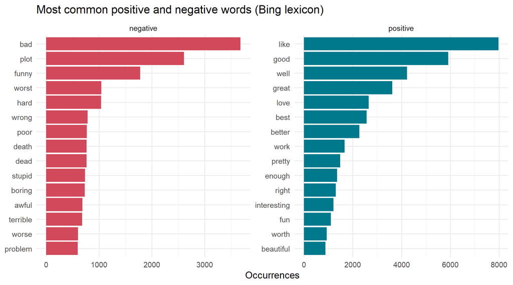

```r
words_only |>
  inner_join(bing, by = "word") |>
  count(word, sentiment, sort = TRUE) |>
  group_by(sentiment) |>
  slice_max(n, n = 15, with_ties = FALSE) |>
  ungroup() |>
  mutate(word = reorder_within(word, n, sentiment)) |>
  ggplot(aes(n, word, fill = sentiment)) +
  geom_col(show.legend = FALSE) +
  scale_y_reordered() +
  scale_fill_manual(values = c(negative = "#d1495b", positive = "#00798c")) +
  facet_wrap(~ sentiment, scales = "free") +
  labs(title = "Most common positive and negative words (Bing lexicon)",
       x = "Occurrences", y = NULL)
```

Note *plot*, *funny* and *like*: lexicon words whose meaning in a movie review is not always opinion (see Limitations).

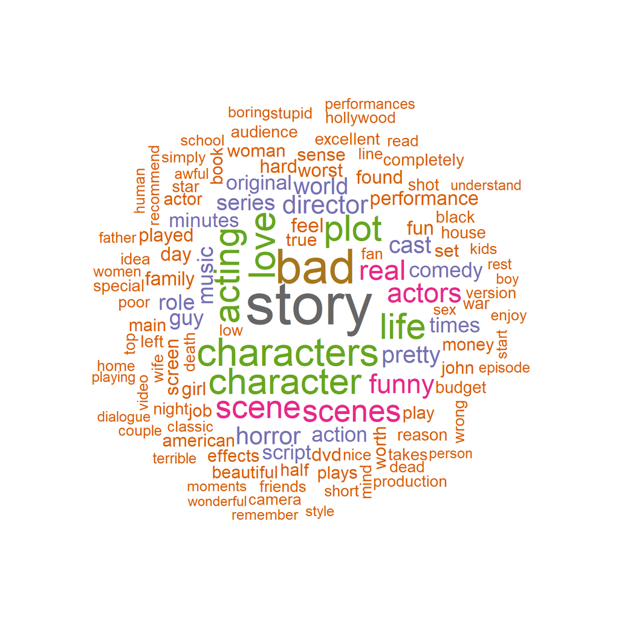

```r
par(mar = rep(0, 4))
word_counts |>
  anti_join(domain_stop, by = "word") |>
  with(wordcloud(word, n, max.words = 120, random.order = FALSE,
                 rot.per = 0.15, colors = brewer.pal(8, "Dark2")))
```

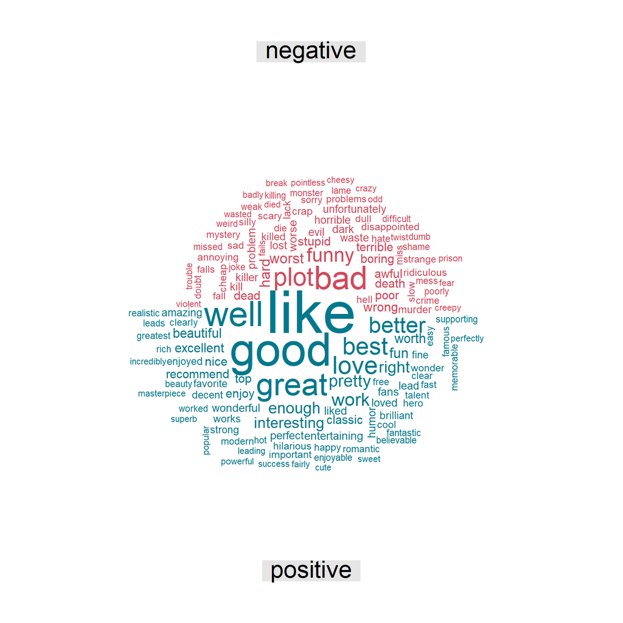

```r
par(mar = rep(0, 4))
words_only |>
  inner_join(bing, by = "word") |>
  count(word, sentiment, sort = TRUE) |>
  acast(word ~ sentiment, value.var = "n", fill = 0) |>
  comparison.cloud(colors = c("#d1495b", "#00798c"), max.words = 150,
                   title.size = 1.6)
```

**NRC emotions.** Share of emotion words falling into each emotion, by the true review label:

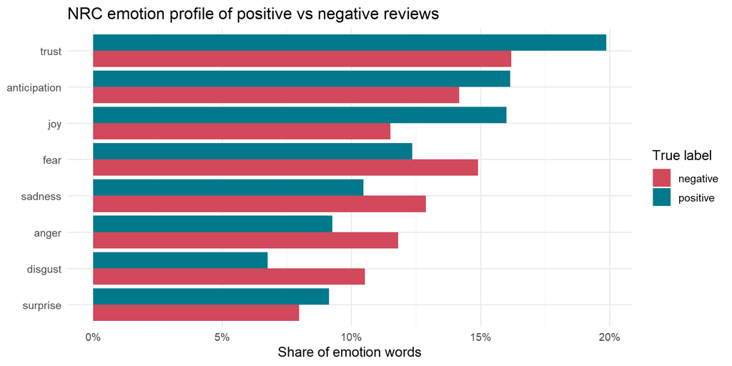

```r
tokens_all |>
  rename(review_label = sentiment) |>
  inner_join(filter(nrc, !sentiment %in% c("positive", "negative")),
             by = "word", relationship = "many-to-many") |>
  count(review_label, emotion = sentiment) |>
  group_by(review_label) |>
  mutate(share = n / sum(n)) |>
  ungroup() |>
  ggplot(aes(share, fct_reorder(emotion, share), fill = review_label)) +
  geom_col(position = "dodge") +
  scale_x_continuous(labels = percent) +
  scale_fill_manual(values = c(negative = "#d1495b", positive = "#00798c")) +
  labs(title = "NRC emotion profile of positive vs negative reviews",
       x = "Share of emotion words", y = NULL, fill = "True label")
```

## 6.1 Sentiment by topic

The three lexicon scores have different scales, so each is standardised (z-score) before being averaged per topic. The share of truly positive reviews in each topic is shown alongside as ground truth.

```r
topic_sentiment <- scored |>
  mutate(across(c(afinn, bing, nrc), \(x) as.numeric(scale(x)), .names = "{.col}_z")) |>
  group_by(topic_label) |>
  summarise(reviews        = n(),
            pct_positive   = mean(sentiment == "positive"),
            mean_stars     = mean(rating),
            AFINN          = mean(afinn_z),
            Bing           = mean(bing_z),
            NRC            = mean(nrc_z)) |>
  arrange(desc(AFINN))

topic_sentiment |>
  mutate(pct_positive = percent(pct_positive, accuracy = 0.1),
         across(c(mean_stars, AFINN, Bing, NRC), \(x) round(x, 2)))
```

| topic_label | reviews | pct_positive | mean_stars | AFINN | Bing | NRC |
| --- | --- | --- | --- | --- | --- | --- |
| Music, love & family viewing | 1070 | 83.4% | 8.05 | 0.63 | 0.65 | 0.42 |
| Comedy & humour | 675 | 49.5% | 5.42 | 0.46 | -0.04 | -0.06 |
| Action & special effects | 189 | 62.4% | 6.50 | 0.37 | 0.41 | 0.20 |
| Acting & performances | 3140 | 59.7% | 6.18 | 0.22 | 0.24 | 0.34 |
| TV series & episodes | 448 | 64.1% | 6.62 | 0.18 | 0.18 | 0.09 |
| Book adaptations | 259 | 43.6% | 5.06 | 0.09 | 0.10 | -0.01 |
| War, history & documentaries | 1776 | 44.3% | 5.05 | -0.26 | -0.19 | -0.09 |
| Horror & slashers | 526 | 41.8% | 4.97 | -0.34 | -0.47 | -0.66 |
| Family & thriller plots | 610 | 48.5% | 5.35 | -0.37 | -0.34 | -0.30 |
| Bad acting & wasted money | 1307 | 6.0% | 2.13 | -0.76 | -0.61 | -0.65 |

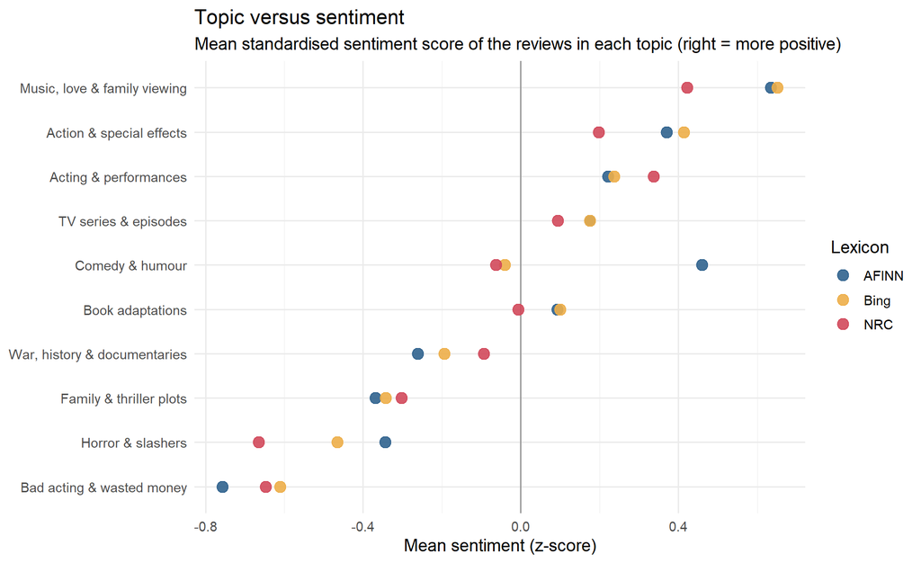

```r
topic_sentiment |>
  pivot_longer(c(AFINN, Bing, NRC), names_to = "lexicon", values_to = "z") |>
  mutate(topic_label = fct_reorder(topic_label, z, .fun = mean)) |>
  ggplot(aes(z, topic_label, colour = lexicon)) +
  geom_vline(xintercept = 0, colour = "grey60") +
  geom_point(size = 3.5, alpha = 0.9) +
  scale_colour_manual(values = c(AFINN = "#30638e", Bing = "#edae49", NRC = "#d1495b")) +
  labs(title = "Topic versus sentiment",
       subtitle = "Mean standardised sentiment score of the reviews in each topic (right = more positive)",
       x = "Mean sentiment (z-score)", y = NULL, colour = "Lexicon")
```

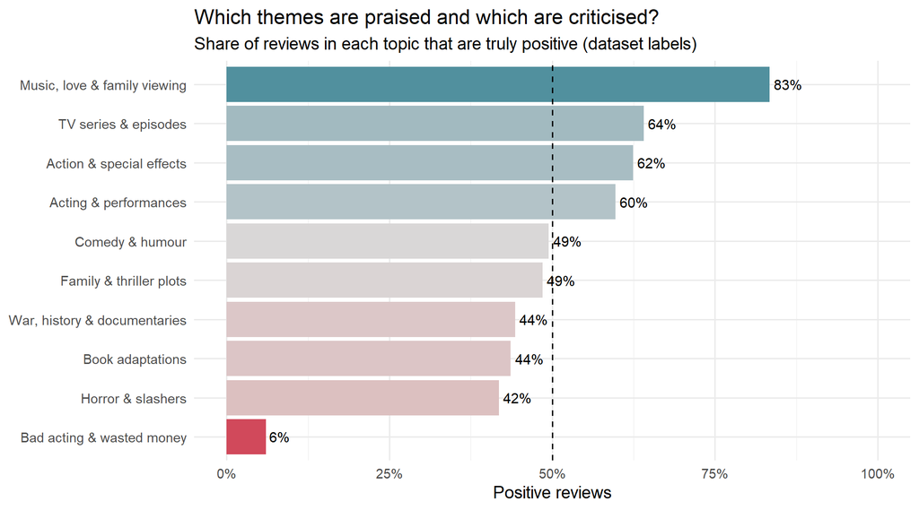

```r
topic_sentiment |>
  mutate(topic_label = fct_reorder(topic_label, pct_positive)) |>
  ggplot(aes(pct_positive, topic_label, fill = pct_positive)) +
  geom_col(show.legend = FALSE) +
  geom_vline(xintercept = 0.5, linetype = "dashed") +
  geom_text(aes(label = percent(pct_positive, accuracy = 1)), hjust = -0.15, size = 3.5) +
  scale_fill_gradient2(low = "#d1495b", mid = "grey85", high = "#00798c", midpoint = 0.5) +
  scale_x_continuous(labels = percent, limits = c(0, 1)) +
  labs(title = "Which themes are praised and which are criticised?",
       subtitle = "Share of reviews in each topic that are truly positive (dataset labels)",
       x = "Positive reviews", y = NULL)
```

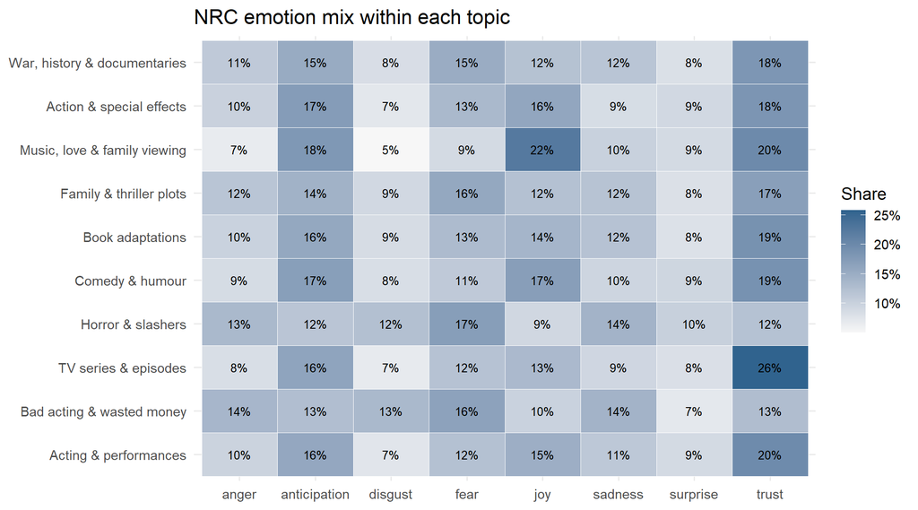

```r
scored |>
  select(id, topic_label) |>
  left_join(nrc_emotions, by = "id") |>
  mutate(across(-c(id, topic_label), \(x) coalesce(x, 0L))) |>
  pivot_longer(-c(id, topic_label), names_to = "emotion", values_to = "n") |>
  group_by(topic_label, emotion) |>
  summarise(n = sum(n), .groups = "drop_last") |>
  mutate(share = n / sum(n)) |>
  ungroup() |>
  ggplot(aes(emotion, topic_label, fill = share)) +
  geom_tile(colour = "white") +
  geom_text(aes(label = percent(share, accuracy = 1)), size = 3) +
  scale_fill_gradient(low = "#f7f7f7", high = "#30638e", labels = percent) +
  labs(title = "NRC emotion mix within each topic",
       x = NULL, y = NULL, fill = "Share")
```

# 7 Stage 6 – Validation against the dataset labels

A review is predicted **positive** when its lexicon score is above 0 and **negative** otherwise.

```r
truth <- factor(scored$sentiment, levels = c("negative", "positive"))
predict_label <- function(score) factor(ifelse(score > 0, "positive", "negative"),
                                        levels = c("negative", "positive"))

cms <- list(
  AFINN = confusionMatrix(predict_label(scored$afinn), truth, positive = "positive"),
  Bing  = confusionMatrix(predict_label(scored$bing),  truth, positive = "positive"),
  NRC   = confusionMatrix(predict_label(scored$nrc),   truth, positive = "positive")
)

lexicon_accuracy <- tibble(
  method      = names(cms),
  accuracy    = sapply(cms, \(cm) cm$overall["Accuracy"]),
  sensitivity = sapply(cms, \(cm) cm$byClass["Sensitivity"]),
  specificity = sapply(cms, \(cm) cm$byClass["Specificity"]),
  kappa       = sapply(cms, \(cm) cm$overall["Kappa"]),
  zero_score  = c(mean(scored$afinn == 0), mean(scored$bing == 0), mean(scored$nrc == 0))
)

lexicon_accuracy |> mutate(across(-method, \(x) round(x, 3)))
```

| method | accuracy | sensitivity | specificity | kappa | zero_score |
| --- | --- | --- | --- | --- | --- |
| AFINN | 0.700 | 0.840 | 0.560 | 0.400 | 0.032 |
| Bing | 0.734 | 0.741 | 0.726 | 0.467 | 0.066 |
| NRC | 0.652 | 0.807 | 0.497 | 0.304 | 0.068 |

Sensitivity is recall on positive reviews; specificity is recall on negative reviews. AFINN and NRC lean strongly positive (high sensitivity, low specificity): negative reviews still use many positive words (“good actors, *but*…”). Bing is the most balanced of the three, partly because it counts words such as *plot* and *funny* as negative.

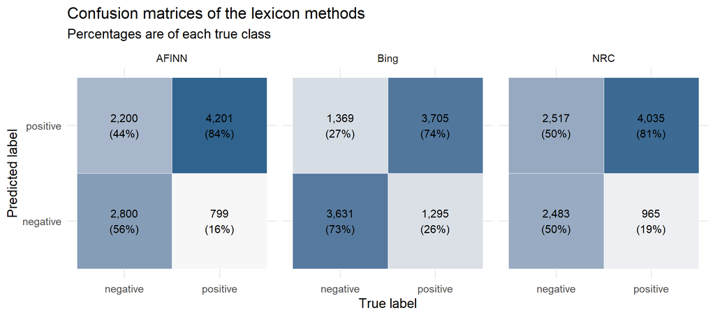

```r
lapply(names(cms), function(m) {
  as_tibble(cms[[m]]$table) |> mutate(method = m)
}) |>
  bind_rows() |>
  group_by(method, Reference) |>
  mutate(pct = n / sum(n)) |>
  ungroup() |>
  ggplot(aes(Reference, Prediction, fill = pct)) +
  geom_tile(colour = "white") +
  geom_text(aes(label = paste0(comma(n), "\n(", percent(pct, accuracy = 1), ")")), size = 3.5) +
  scale_fill_gradient(low = "#f7f7f7", high = "#30638e", guide = "none") +
  facet_wrap(~ method) +
  labs(title = "Confusion matrices of the lexicon methods",
       subtitle = "Percentages are of each true class",
       x = "True label", y = "Predicted label")
```

## 7.1 Improvement 1: simple negation handling

Dictionary methods miss negation (*not good*). A small fix: flip the AFINN score of a word when one of the two preceding words is a negator.

```r
negators <- c("not", "no", "never", "without", "nothing", "isn't", "wasn't",
              "aren't", "don't", "doesn't", "didn't", "can't", "couldn't",
              "won't", "wouldn't", "hardly", "nor", "neither")

afinn_neg <- words_only |>
  group_by(id) |>
  mutate(prev1 = lag(word, 1), prev2 = lag(word, 2)) |>
  ungroup() |>
  inner_join(afinn, by = "word") |>
  mutate(negated = coalesce(prev1 %in% negators | prev2 %in% negators, FALSE),
         value   = if_else(negated, -value, value)) |>
  group_by(id) |>
  summarise(afinn_negation = sum(value), negated_words = sum(negated))

scored <- scored |>
  left_join(afinn_neg, by = "id") |>
  mutate(afinn_negation = coalesce(afinn_negation, 0))

cm_neg <- confusionMatrix(predict_label(scored$afinn_negation), truth, positive = "positive")

words_only |>
  group_by(id) |> mutate(prev1 = lag(word)) |> ungroup() |>
  filter(prev1 %in% negators) |>
  inner_join(afinn, by = "word") |>
  count(phrase = paste(prev1, word), value, sort = TRUE) |>
  slice_head(n = 10)
```

| phrase | value | n |
| --- | --- | --- |
| no matter | 1 | 142 |
| don’t waste | -1 | 113 |
| don’t want | 1 | 110 |
| don’t like | 2 | 108 |
| not funny | 4 | 100 |
| not like | 2 | 98 |
| not worth | 2 | 90 |
| no doubt | -1 | 89 |
| didn’t like | 2 | 83 |
| don’t care | 2 | 78 |

```r
tibble(method = c("AFINN", "AFINN + negation"),
       accuracy = c(cms$AFINN$overall["Accuracy"], cm_neg$overall["Accuracy"])) |>
  mutate(accuracy = round(accuracy, 3))
```

| method | accuracy |
| --- | --- |
| AFINN | 0.700 |
| AFINN + negation | 0.714 |

## 7.2 Improvement 2: a supervised classifier (logistic regression)

The lexicons use no training data. For comparison, a lasso-regularised logistic regression is trained on the same tf-idf document-term matrix (80 % train / 20 % test, split stratified by label).

```r
y <- factor(reviews$sentiment, levels = c("negative", "positive"))
train_idx <- createDataPartition(y, p = 0.8, list = FALSE)[, 1]

cv_fit <- cv.glmnet(dtm[train_idx, ], y[train_idx], family = "binomial",
                    alpha = 1, type.measure = "class", nfolds = 5)

test_prob <- predict(cv_fit, dtm[-train_idx, ], s = "lambda.min", type = "response")[, 1]
test_pred <- factor(ifelse(test_prob > 0.5, "positive", "negative"),
                    levels = c("negative", "positive"))
cm_glm <- confusionMatrix(test_pred, y[-train_idx], positive = "positive")
cm_glm
```

```
## Confusion Matrix and Statistics
##
##           Reference
## Prediction negative positive
##   negative      815      119
##   positive      185      881
##
##                Accuracy : 0.848
##                  95% CI : (0.8315, 0.8635)
##     No Information Rate : 0.5
##     P-Value [Acc > NIR] : < 2.2e-16
##
##                   Kappa : 0.696
##
##  Mcnemar's Test P-Value : 0.000193
##
##             Sensitivity : 0.8810
##             Specificity : 0.8150
##          Pos Pred Value : 0.8265
##          Neg Pred Value : 0.8726
##              Prevalence : 0.5000
##          Detection Rate : 0.4405
##    Detection Prevalence : 0.5330
##       Balanced Accuracy : 0.8480
##
##        'Positive' Class : positive
##
```

```r
coefs <- coef(cv_fit, s = "lambda.min")
coef_tbl <- tibble(term = rownames(coefs), weight = as.numeric(coefs)) |>
  filter(term != "(Intercept)", weight != 0)

cat("Terms kept by the lasso:", nrow(coef_tbl), "of", length(vocab), "\n")
```

```
## Terms kept by the lasso: 1012 of 5724
```

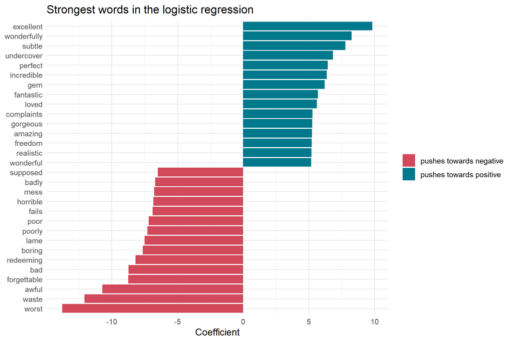

```r
bind_rows(slice_max(coef_tbl, weight, n = 15), slice_min(coef_tbl, weight, n = 15)) |>
  mutate(direction = if_else(weight > 0, "pushes towards positive", "pushes towards negative")) |>
  ggplot(aes(weight, fct_reorder(term, weight), fill = direction)) +
  geom_col() +
  scale_fill_manual(values = c("pushes towards negative" = "#d1495b",
                               "pushes towards positive" = "#00798c")) +
  labs(title = "Strongest words in the logistic regression",
       x = "Coefficient", y = NULL, fill = NULL)
```

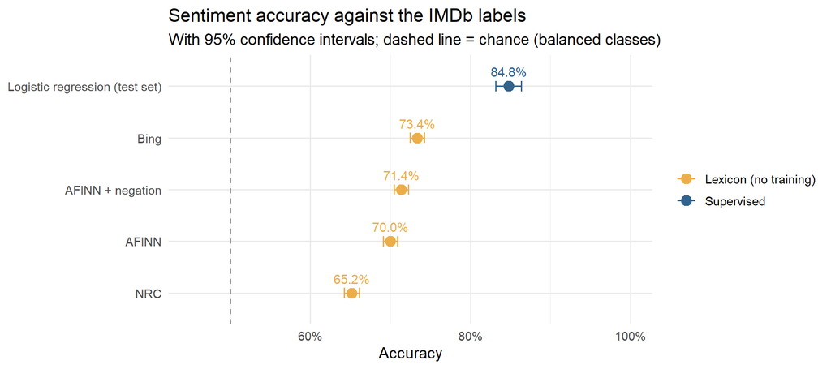

```r
accuracy_summary <- tibble(
  method   = c("AFINN", "Bing", "NRC", "AFINN + negation", "Logistic regression (test set)"),
  type     = c(rep("Lexicon (no training)", 4), "Supervised"),
  accuracy = c(cms$AFINN$overall["Accuracy"], cms$Bing$overall["Accuracy"],
               cms$NRC$overall["Accuracy"],   cm_neg$overall["Accuracy"],
               cm_glm$overall["Accuracy"]),
  lower_95 = c(cms$AFINN$overall["AccuracyLower"], cms$Bing$overall["AccuracyLower"],
               cms$NRC$overall["AccuracyLower"],   cm_neg$overall["AccuracyLower"],
               cm_glm$overall["AccuracyLower"]),
  upper_95 = c(cms$AFINN$overall["AccuracyUpper"], cms$Bing$overall["AccuracyUpper"],
               cms$NRC$overall["AccuracyUpper"],   cm_neg$overall["AccuracyUpper"],
               cm_glm$overall["AccuracyUpper"])
)

ggplot(accuracy_summary, aes(accuracy, fct_reorder(method, accuracy), colour = type)) +
  geom_vline(xintercept = 0.5, linetype = "dashed", colour = "grey60") +
  geom_errorbarh(aes(xmin = lower_95, xmax = upper_95), height = 0.2) +
  geom_point(size = 3.5) +
  geom_text(aes(label = percent(accuracy, accuracy = 0.1)), vjust = -1, size = 3.5,
            show.legend = FALSE) +
  scale_x_continuous(labels = percent, limits = c(0.45, 1)) +
  scale_colour_manual(values = c("Lexicon (no training)" = "#edae49", Supervised = "#30638e")) +
  labs(title = "Sentiment accuracy against the IMDb labels",
       subtitle = "With 95% confidence intervals; dashed line = chance (balanced classes)",
       x = "Accuracy", y = NULL, colour = NULL)
```

## 7.3 Explaining predictions with LIME

LIME perturbs a review by removing words and fits a simple local model to see which words drove the classifier’s decision for that particular review.

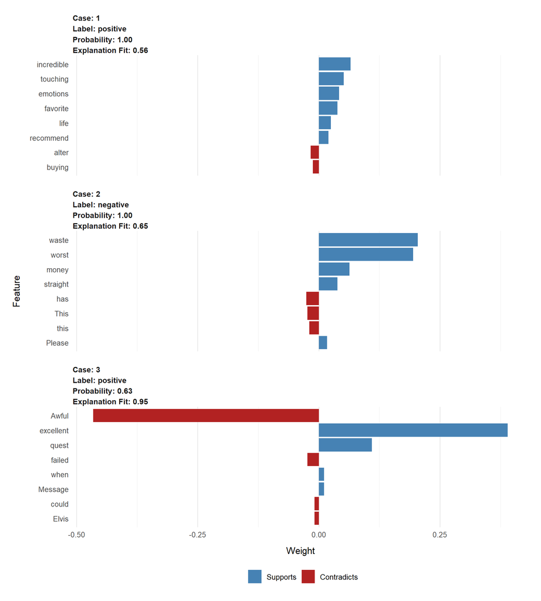

```r
lime_model <- structure(list(fit = cv_fit), class = "imdb_lasso")

registerS3method("model_type", "imdb_lasso",
                 function(x, ...) "classification", envir = asNamespace("lime"))
registerS3method("predict_model", "imdb_lasso", function(x, newdata, type, ...) {
  p <- predict(x$fit, text_to_dtm(newdata), s = "lambda.min", type = "response")[, 1]
  data.frame(negative = 1 - p, positive = p)
}, envir = asNamespace("lime"))

test_reviews <- reviews[-train_idx, ] |>
  mutate(prob = test_prob, review_text = str_replace_all(review, "<[^>]+>", " "))

# one confident positive, one confident negative, one the model got wrong
to_explain <- bind_rows(
  test_reviews |> filter(sentiment == "positive", n_words < 150) |> slice_max(prob, n = 1),
  test_reviews |> filter(sentiment == "negative", n_words < 150) |> slice_min(prob, n = 1),
  test_reviews |> filter(n_words < 150,
                         (sentiment == "positive") != (prob > 0.5)) |> slice(1)
)

explainer <- lime(reviews$review[train_idx], lime_model)
explanation <- explain(to_explain$review_text, explainer, n_labels = 1,
                       n_features = 8, n_permutations = 1000)

plot_features(explanation, ncol = 1)
```

```r
to_explain |>
  transmute(case = c("confident positive", "confident negative", "misclassified"),
            true_label = sentiment, predicted_p_positive = round(prob, 3),
            text = str_trunc(str_squish(review_text), 300))
```

| case | true_label | predicted_p_positive | text |
| --- | --- | --- | --- |
| confident positive | positive | 1.000 | Really…and incredible film that though isn’t very popular…extremely touching and almost life altering…was for me at least. Definitely worth seeing and buying …..Added to my favorite movie list….it’s n… |
| confident negative | negative | 0.000 | This was really the worst movie I’ve ever seen. Anyone who has seen it will know what I’m talking about. I saw it on Starz, so thank goodness I didn’t waste my money. Please everyone, don’t waste your… |
| misclassified | negative | 0.628 | Maybe I was to young when I saw it. Perhaps I have not grown up with Grease and Elvis movies. I failed to get it. I get “black” comedy (Black Adder etc.). I get irony and spoofs. I don’t get this one … |

# 8 Save outputs

```r
write_csv(topic_terms, "outputs/lsa_topic_terms.csv")
write_csv(topic_sentiment, "outputs/topic_sentiment.csv")
write_csv(accuracy_summary, "outputs/sentiment_accuracy.csv")
write_csv(select(scored, id, sentiment, rating, topic, topic_label,
                 afinn, afinn_negation, bing, nrc),
          "outputs/review_scores.csv")
list.files("outputs", recursive = TRUE)
```

```
##  [1] "figures/all-accuracy-1.png"          "figures/assign-1.png"
##  [3] "figures/confusion-plot-1.png"        "figures/eda-plots-1.png"
##  [5] "figures/eda-plots-2.png"             "figures/lime-1.png"
##  [7] "figures/logreg-coefs-1.png"          "figures/nrc-emotions-1.png"
##  [9] "figures/scree-1.png"                 "figures/tfidf-rating-1.png"
## [11] "figures/top-sentiment-words-1.png"   "figures/topic-emotion-heatmap-1.png"
## [13] "figures/topic-sentiment-plot-1.png"  "figures/topic-terms-plot-1.png"
## [15] "figures/topic-truth-plot-1.png"      "figures/word-freq-1.png"
## [17] "figures/wordcloud-all-1.png"         "figures/wordcloud-compare-1.png"
## [19] "figures/zipf-1.png"                  "lsa_topic_terms.csv"
## [21] "review_scores.csv"                   "sentiment_accuracy.csv"
## [23] "topic_sentiment.csv"
```

# 9 Summary of findings

- **Topics.** LSA with k = 10 varimax-rotated dimensions recovers interpretable themes (see the topic chart). The most praised theme is **Music, love & family viewing** (83% of its reviews are positive); the most criticised is **Bad acting & wasted money** (6% positive).
- **Lexicon sentiment.** Accuracy against the labels: AFINN 70.0%, Bing 73.4%, NRC 65.2%. AFINN and NRC over-predict the positive class; Bing is the most balanced and the most accurate lexicon. Simple negation handling moves AFINN to 71.4%.
- **Supervised model.** Lasso logistic regression on the same tf-idf features reaches 84.8% on held-out reviews, showing how much a model trained on movie-review language gains over general-purpose dictionaries.
- **Limitations confirmed.** Words like *plot*, *funny*, *like* and *kill* are mis-scored by lexicons in a movie context; LSA needs a rotation and manual judgement of k to give readable topics; LDA, transformer sentiment models and aspect-level sentiment remain the natural next steps.

```
## R4.6.1 | 10000 reviews analysed | seed 2026
```